# A national longitudinal study of religion and climate beliefs/behaviours | New Zealand

Biola Jan 9 2021

## We investigate the following beliefs

1. Climate beliefs: climate change: (a) is real (b) is human caused
2. Climate concern
3. Beliefs that my behaviour can protect the environment
4. Sacrificial behaviour for the environment

## Model: within + between person trends

\[ \begin{aligned} \operatorname{outcome}_{i} &\sim N \left(\mu, \sigma^2 \right) \\ \mu &=\alpha_{j[i],k[i]} + \beta_{1}(\operatorname{years}) + \beta_{0k[i]}(\operatorname{Rel\_win}) \\ \left( \begin{array}{c} \begin{aligned} &\alpha_{j} \\ &\gamma_{1j} \end{aligned} \end{array} \right) &\sim N \left( \left( \begin{array}{c} \begin{aligned} &\gamma_{0}^{\alpha} + \gamma_{1}^{\alpha}(\operatorname{Rel\_betw}) + \gamma_{2}^{\alpha}(\operatorname{Rel\_betw} \times \operatorname{years}) \\ &\mu_{\gamma_{1j}} \end{aligned} \end{array} \right) , \left( \begin{array}{cc} \sigma^2_{\alpha_{j}} & \rho_{\alpha_{j}\gamma_{1j}} \\ \rho_{\gamma_{1j}\alpha_{j}} & \sigma^2_{\gamma_{1j}} \end{array} \right) \right) \text{, for Id j = 1,} \dots \text{,J} \\ \left( \begin{array}{c} \begin{aligned} &\alpha_{k} \\ &\beta_{0k} \end{aligned} \end{array} \right) &\sim N \left( \left( \begin{array}{c} \begin{aligned} &\mu_{\alpha_{k}} \\ &\mu_{\beta_{0k}} \end{aligned} \end{array} \right) , \left( \begin{array}{cc} \sigma^2_{\alpha_{k}} & \rho_{\alpha_{k}\beta_{0k}} \\ \rho_{\beta_{0k}\alpha_{k}} & \sigma^2_{\beta_{0k}} \end{array} \right) \right) \text{, for Id.1 k = 1,} \dots \text{,K} \end{aligned} \]

## Climate Beliefs

“Climate change is real.”

## Climate change reality

### conservativism between: strong upward trend with large political divisions

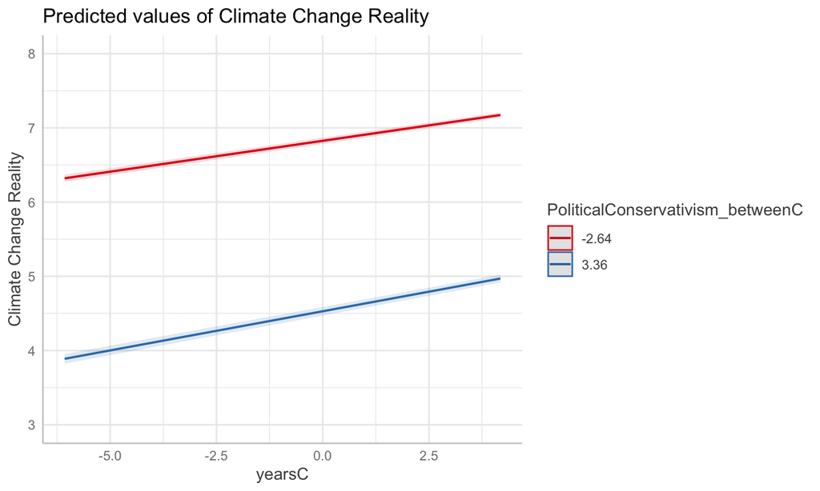

## Climate change reality

### political conservativism within moves in the same direction

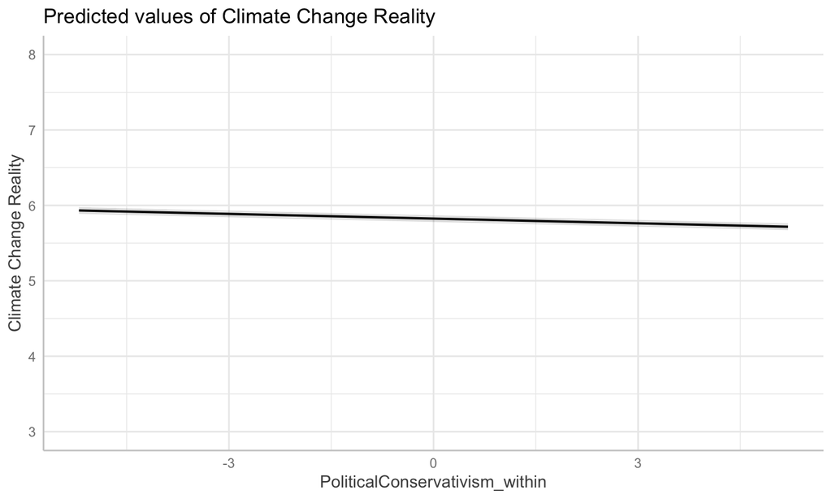

## Climate change reality

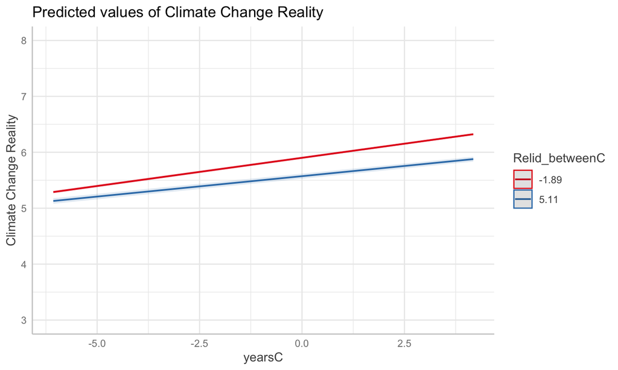

## Climate change reality

### religious identification within moves against the between group trend

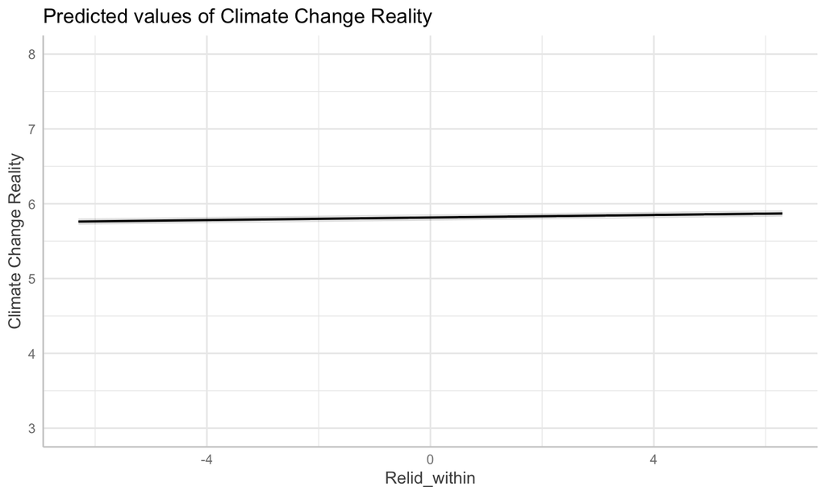

## Climate change reality

### religious identification

|  | Climate Change Reality |  |  |
| --- | --- | --- | --- |
| Predictors | Estimates | CI | p |
| (Intercept) | 5.81 | 5.80 – 5.83 | **<0.001** |
| yearsC | 0.09 | 0.09 – 0.10 | **<0.001** |
| Relid_betweenC | -0.05 | -0.05 – -0.04 | **<0.001** |
| Relid_within | 0.01 | 0.00 – 0.01 | **0.006** |
| yearsC * Relid_betweenC | -0.00 | -0.00 – -0.00 | **<0.001** |
| Random Effects |  |  |  |
| σ<sup>2</sup> | 0.75 |  |  |
| τ<sub>00</sub> <sub>Id</sub> | 0.58 |  |  |
| τ<sub>00</sub> <sub>Id.1</sub> | 0.64 |  |  |
| τ<sub>11</sub> <sub>Id.Relid_betweenC</sub> | 0.02 |  |  |
| τ<sub>11</sub> <sub>Id.1.Relid_within</sub> | 0.01 |  |  |
| ρ<sub>01</sub> <sub>Id</sub> | 0.19 |  |  |
| ρ<sub>01</sub> <sub>Id.1</sub> | 0.01 |  |  |
| ICC | 0.48 |  |  |
| N <sub>Id</sub> | 26700 |  |  |
| Observations | 122544 |  |  |

## Beliefs in Human Caused Climate Change

> “Climate change is caused by humans.”

## Human-caused climate change

### political conservativism between = similar story

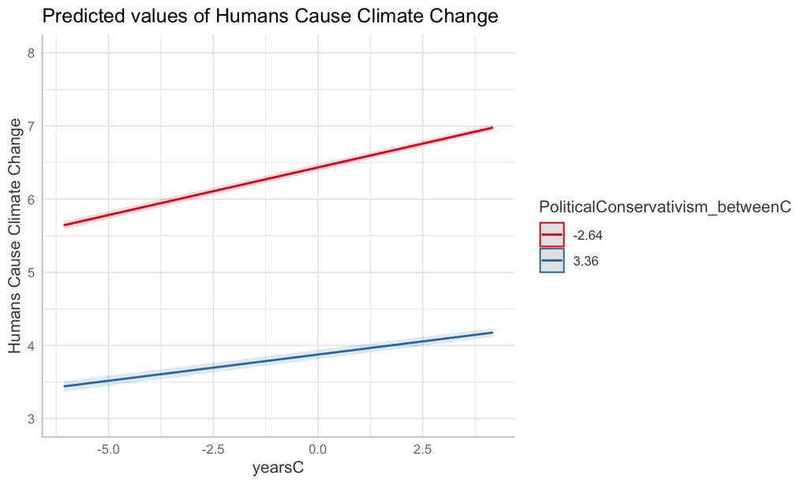

## Human-caused climate change

### political conservativism within = similar story

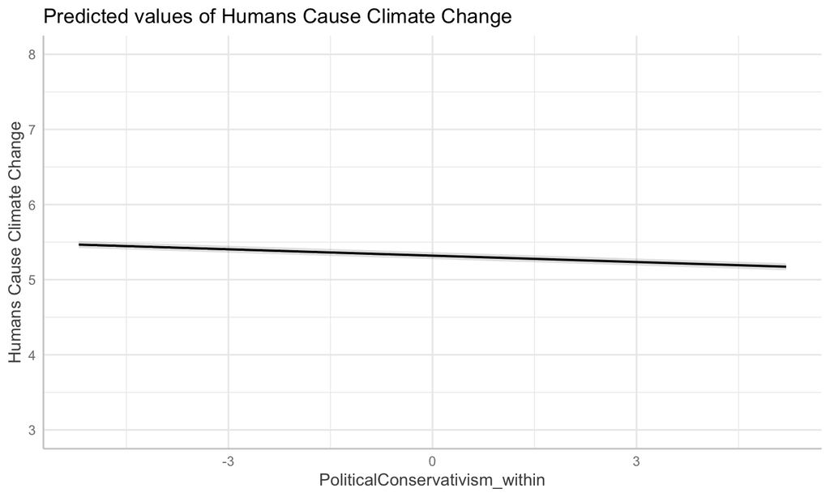

## Human-caused climate change

### religious identification between = similar story

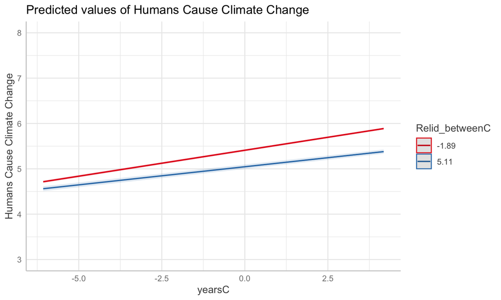

## Human-caused climate change

### religious identification within = similar story

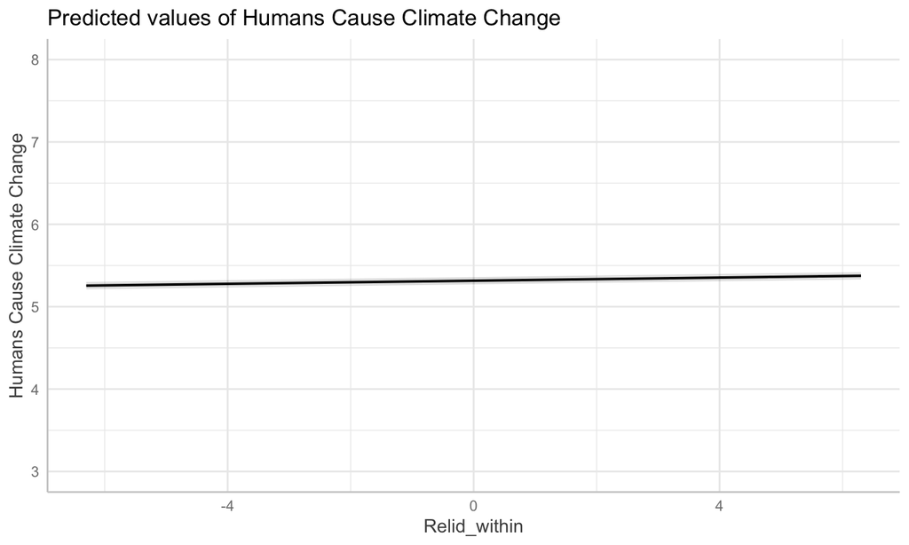

## Human-caused climate change

### religious identification

|  | Humans Cause Climate Change |  |  |
| --- | --- | --- | --- |
| Predictors | Estimates | CI | p |
| (Intercept) | 5.31 | 5.29 – 5.33 | **<0.001** |
| yearsC | 0.11 | 0.10 – 0.11 | **<0.001** |
| Relid_betweenC | -0.05 | -0.06 – -0.04 | **<0.001** |
| Relid_within | 0.01 | 0.00 – 0.02 | **0.005** |
| yearsC * Relid_betweenC | -0.00 | -0.01 – -0.00 | **<0.001** |
| Random Effects |  |  |  |
| σ<sup>2</sup> | 0.80 |  |  |
| τ<sub>00</sub> <sub>Id</sub> | 0.69 |  |  |
| τ<sub>00</sub> <sub>Id.1</sub> | 0.93 |  |  |
| τ<sub>11</sub> <sub>Id.Relid_betweenC</sub> | 0.02 |  |  |
| τ<sub>11</sub> <sub>Id.1.Relid_within</sub> | 0.01 |  |  |
| ρ<sub>01</sub> <sub>Id</sub> | 0.04 |  |  |
| ρ<sub>01</sub> <sub>Id.1</sub> | 0.04 |  |  |
| ICC | 0.51 |  |  |
| N <sub>Id</sub> | 26692 |  |  |
| Observations | 122173 |  |  |

## Climate Concern

> “I am deeply concerned about climate change.”

## Climate change concern

### political conservativism between

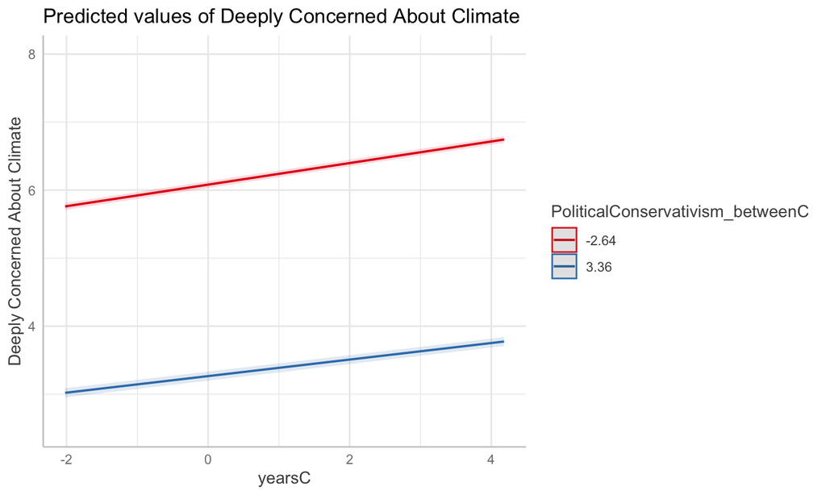

## Climate change is concern

### political conservativism within

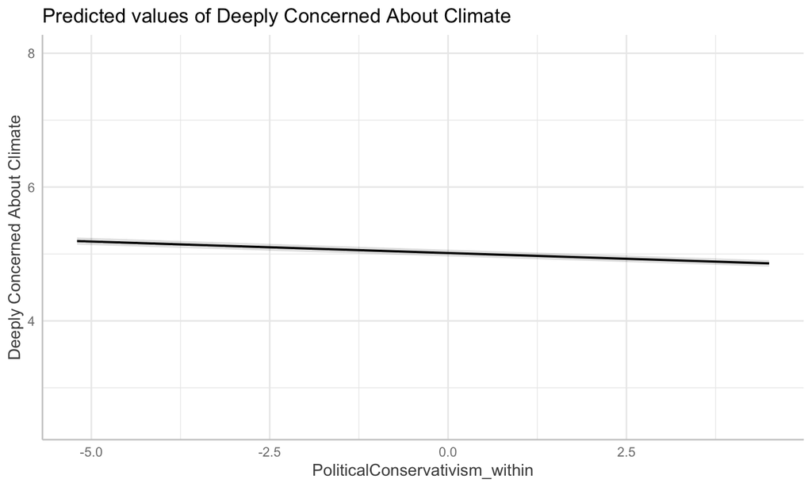

## Climate change is concern

### religious identification between

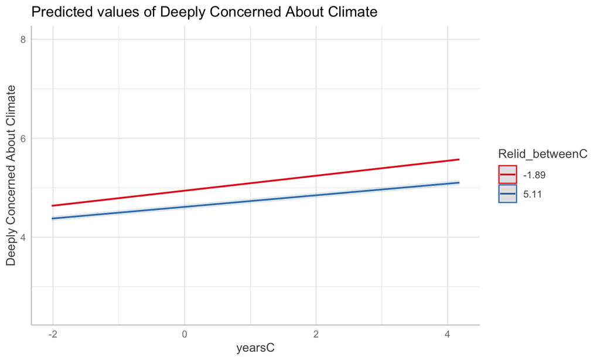

## Climate change is concern

### religious identification within

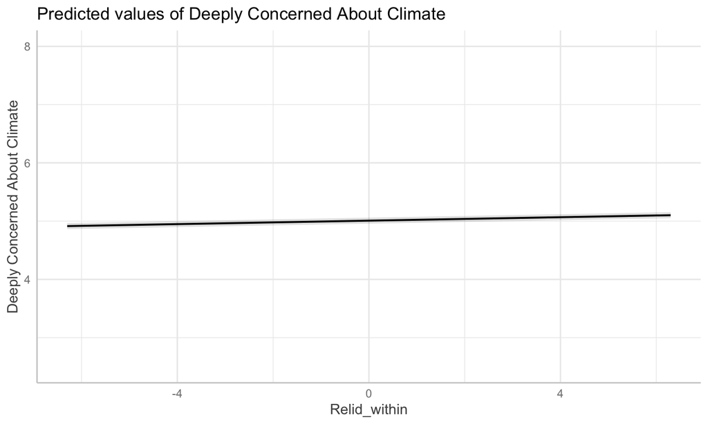

## Climate Efficacy Beliefs

“By taking personal action I believe I can make a positive difference to environmental problems.”

“I feel I can make a difference to the state of the environment”

## Climate change efficacy beliefs: political conservativism between

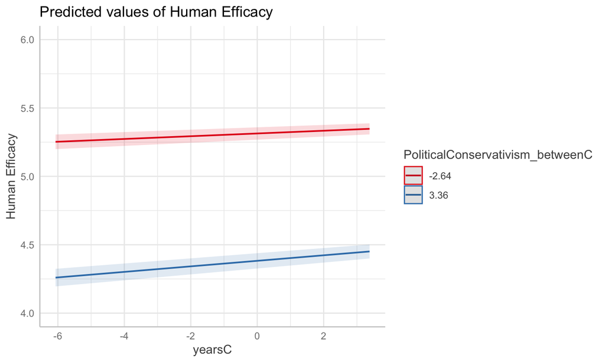

## Climate change efficacy beliefs

### political conservativism within

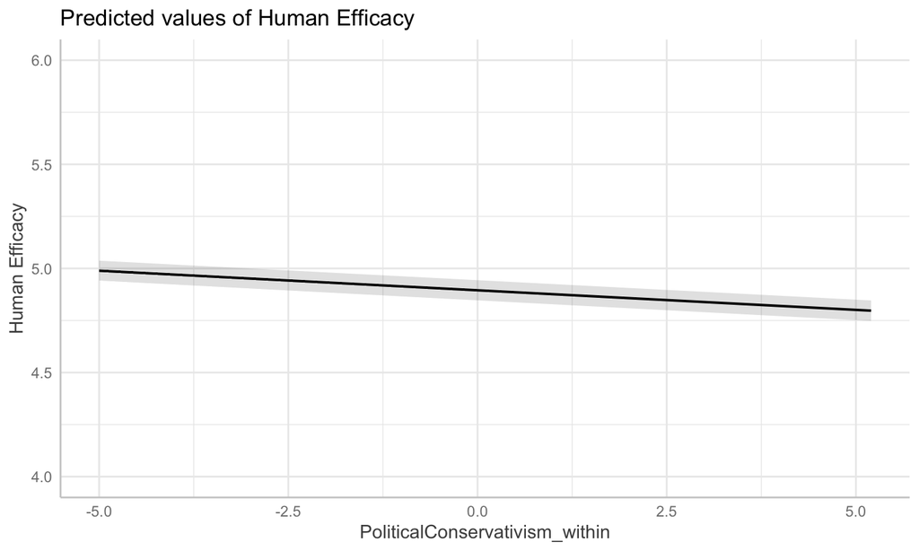

## Climate change efficacy beliefs

### religious identification between

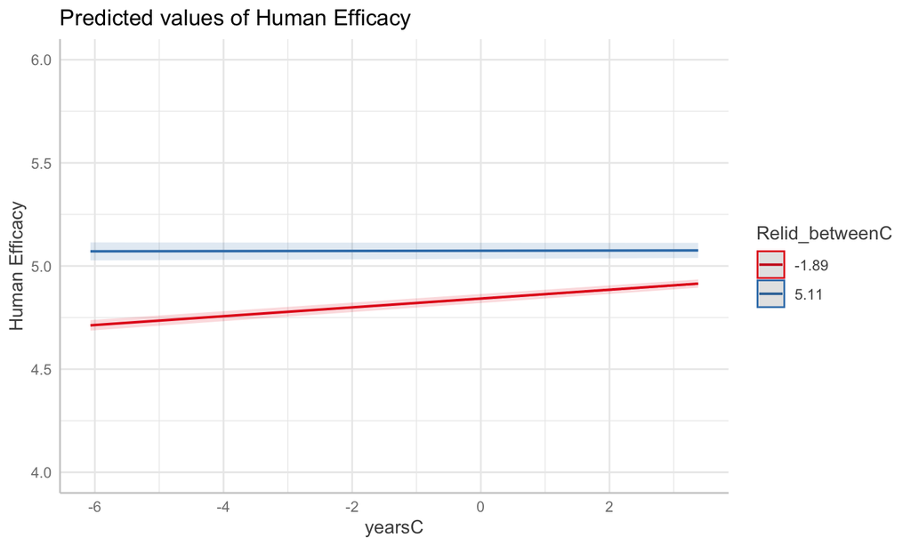

## Climate change efficacy beliefs

### religious identification within

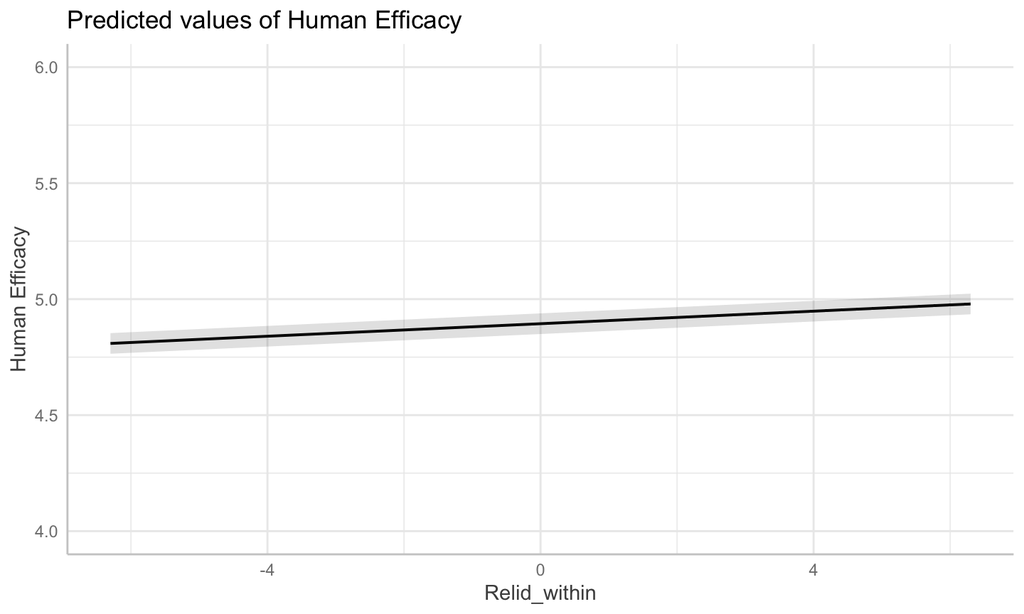

## Climate sacrifice behaviours

> “Have you made sacrifices to your standard of living (e.g., accepted higher prices, driven less, conserved energy) in order to protect the environment?”

## Climate sacrifice behaviours

### political conservativism between

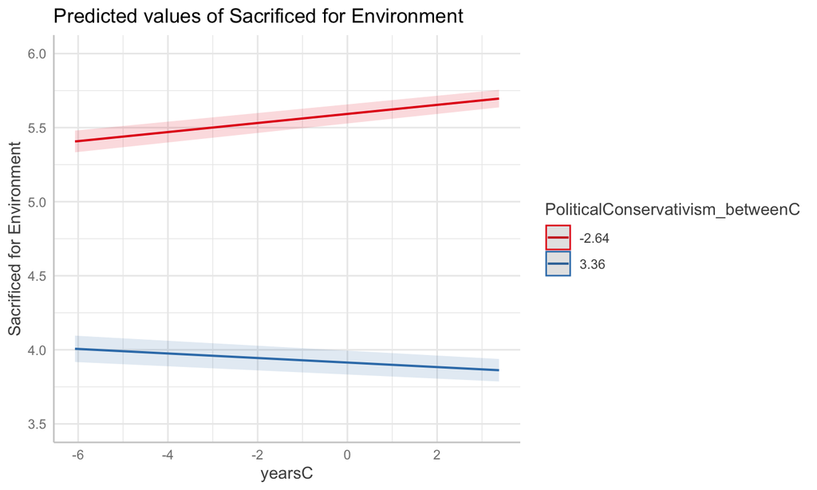

## Climate sacrifice behaviours

### political conservativism within

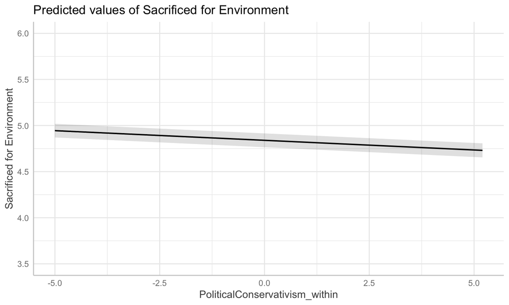

## Climate sacrifice behaviours

### religious identification between

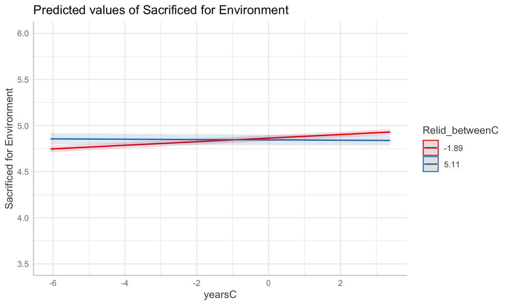

## Climate sacrifice behaviours

### religious identification within

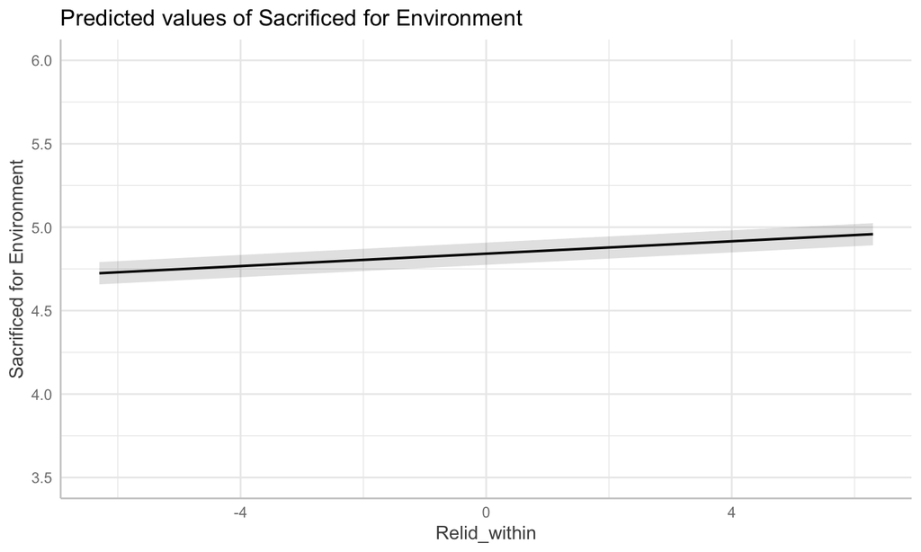

## Summary and Questions

- Compared with a decade ago, New Zealanders are substantially (1) more aware (2) more believing of and concerned about climate change.
- Sacrificial behaviour has been slow to follow this increasing concern.
- Those who become more conservativism are expected to present relatively *diminished environmental beliefs, concerns, and behaviors*, whereas those who become less conservative are expected to present relatively *greater environmental beliefs, concerns, and behaviors*.
- Those who become more religiously identified are expected to present relatively *greater environmental beliefs, concerns, and behaviors*, whereas those who become less religiously identified are expected to present relatively *diminished environmental beliefs, concerns, and behaviors*
- Beware of ecological fallacies! Between-person change is *not* the same as within-person change!
- Question for my fellow IRPSIANS: what are hypotheses might explain why increasing religious identification predicts greater environmental awareness/behavior?

## Thanks to

- Dom Johnson, Oxford University, for the idea to look at the social consequences of religion and ecology.
- Chris G Sibley, University of Auckland for starting & leading the NZAVS.
- The 40 - 60 NZAVS collaborators working to keep the study going, including *Donnie Davis* (virtue project co-investigator), Daryl Van Tongeren & Ev Worthington (collaborators).
- Templeton Religion Trust Grant 0196 for their financial support.
- *You* for your attention and interest!
- Comments/interest to joseph.bulbulia@vuw.ac.nz (some further analyses at: https://github.com/jacopastorius/nzavs_environment)

[figure not shown]

## Extra slide

### Causal DAG clarifies why we don’t simultaneously condition on Religion and Political Conservativism

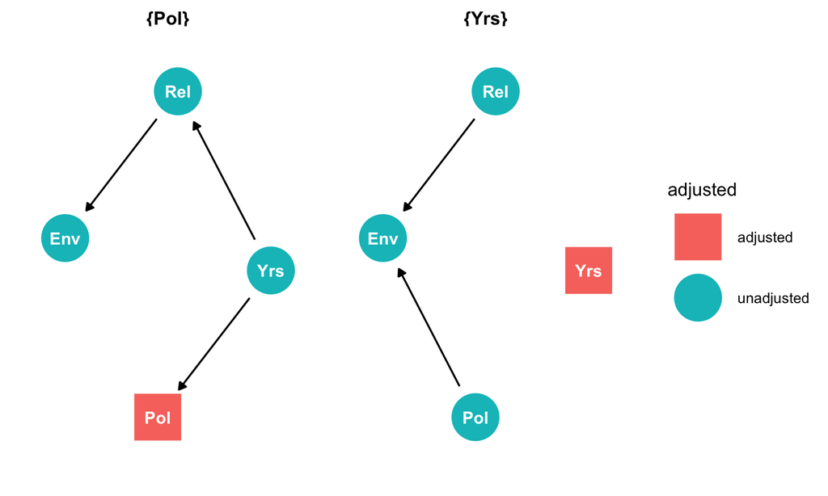

## Extra slide

### Religion Brain & Behaviour: “Retake” format